# Risk Factor Analysis

## Outcome Variable

**Outcome Variable:** ever_stunted

## Predictor Variables

**Intervention Variable:** fage

**Adjustment Set:**

unadjusted

## Stratifying Variables

The analysis was stratified on these variable(s):

- agecat
- studyid
- country

## Data Summary

| agecat | studyid | country | fage | ever_stunted | n_cell | n |
| --- | --- | --- | --- | --- | --- | --- |
| 0-24 months | ki0047075b-MAL-ED | BANGLADESH | >=38 | 0 | 28 | 151 |
| 0-24 months | ki0047075b-MAL-ED | BANGLADESH | >=38 | 1 | 41 | 151 |
| 0-24 months | ki0047075b-MAL-ED | BANGLADESH | <32 | 0 | 7 | 151 |
| 0-24 months | ki0047075b-MAL-ED | BANGLADESH | <32 | 1 | 23 | 151 |
| 0-24 months | ki0047075b-MAL-ED | BANGLADESH | [32-38) | 0 | 23 | 151 |
| 0-24 months | ki0047075b-MAL-ED | BANGLADESH | [32-38) | 1 | 29 | 151 |
| 0-24 months | ki0047075b-MAL-ED | BRAZIL | >=38 | 0 | 22 | 79 |
| 0-24 months | ki0047075b-MAL-ED | BRAZIL | >=38 | 1 | 8 | 79 |
| 0-24 months | ki0047075b-MAL-ED | BRAZIL | <32 | 0 | 10 | 79 |
| 0-24 months | ki0047075b-MAL-ED | BRAZIL | <32 | 1 | 8 | 79 |
| 0-24 months | ki0047075b-MAL-ED | BRAZIL | [32-38) | 0 | 26 | 79 |
| 0-24 months | ki0047075b-MAL-ED | BRAZIL | [32-38) | 1 | 5 | 79 |
| 0-24 months | ki0047075b-MAL-ED | INDIA | >=38 | 0 | 16 | 161 |
| 0-24 months | ki0047075b-MAL-ED | INDIA | >=38 | 1 | 20 | 161 |
| 0-24 months | ki0047075b-MAL-ED | INDIA | <32 | 0 | 19 | 161 |
| 0-24 months | ki0047075b-MAL-ED | INDIA | <32 | 1 | 34 | 161 |
| 0-24 months | ki0047075b-MAL-ED | INDIA | [32-38) | 0 | 25 | 161 |
| 0-24 months | ki0047075b-MAL-ED | INDIA | [32-38) | 1 | 47 | 161 |
| 0-24 months | ki0047075b-MAL-ED | NEPAL | >=38 | 0 | 12 | 79 |
| 0-24 months | ki0047075b-MAL-ED | NEPAL | >=38 | 1 | 5 | 79 |
| 0-24 months | ki0047075b-MAL-ED | NEPAL | <32 | 0 | 9 | 79 |
| 0-24 months | ki0047075b-MAL-ED | NEPAL | <32 | 1 | 6 | 79 |
| 0-24 months | ki0047075b-MAL-ED | NEPAL | [32-38) | 0 | 28 | 79 |
| 0-24 months | ki0047075b-MAL-ED | NEPAL | [32-38) | 1 | 19 | 79 |
| 0-24 months | ki0047075b-MAL-ED | PERU | >=38 | 0 | 10 | 85 |
| 0-24 months | ki0047075b-MAL-ED | PERU | >=38 | 1 | 17 | 85 |
| 0-24 months | ki0047075b-MAL-ED | PERU | <32 | 0 | 8 | 85 |
| 0-24 months | ki0047075b-MAL-ED | PERU | <32 | 1 | 21 | 85 |
| 0-24 months | ki0047075b-MAL-ED | PERU | [32-38) | 0 | 7 | 85 |
| 0-24 months | ki0047075b-MAL-ED | PERU | [32-38) | 1 | 22 | 85 |

[output cut: 204 more lines]

The following strata were considered:

- agecat: 0-24 months, studyid: ki0047075b-MAL-ED, country: BANGLADESH
- agecat: 0-24 months, studyid: ki0047075b-MAL-ED, country: BRAZIL
- agecat: 0-24 months, studyid: ki0047075b-MAL-ED, country: INDIA
- agecat: 0-24 months, studyid: ki0047075b-MAL-ED, country: NEPAL
- agecat: 0-24 months, studyid: ki0047075b-MAL-ED, country: PERU
- agecat: 0-24 months, studyid: ki0047075b-MAL-ED, country: SOUTH AFRICA
- agecat: 0-24 months, studyid: ki0047075b-MAL-ED, country: TANZANIA, UNITED REPUBLIC OF
- agecat: 0-24 months, studyid: ki1000304b-SAS-CompFeed, country: INDIA
- agecat: 0-24 months, studyid: ki1000304b-SAS-FoodSuppl, country: INDIA
- agecat: 0-24 months, studyid: ki1119695-PROBIT, country: BELARUS
- agecat: 0-24 months, studyid: ki1135781-COHORTS, country: GUATEMALA
- agecat: 0-24 months, studyid: ki1135781-COHORTS, country: PHILIPPINES
- agecat: 0-24 months, studyid: ki1148112-LCNI-5, country: MALAWI
- agecat: 0-6 months, studyid: ki0047075b-MAL-ED, country: BANGLADESH
- agecat: 0-6 months, studyid: ki0047075b-MAL-ED, country: BRAZIL
- agecat: 0-6 months, studyid: ki0047075b-MAL-ED, country: INDIA
- agecat: 0-6 months, studyid: ki0047075b-MAL-ED, country: NEPAL
- agecat: 0-6 months, studyid: ki0047075b-MAL-ED, country: PERU
- agecat: 0-6 months, studyid: ki0047075b-MAL-ED, country: SOUTH AFRICA
- agecat: 0-6 months, studyid: ki0047075b-MAL-ED, country: TANZANIA, UNITED REPUBLIC OF
- agecat: 0-6 months, studyid: ki1000304b-SAS-CompFeed, country: INDIA
- agecat: 0-6 months, studyid: ki1000304b-SAS-FoodSuppl, country: INDIA
- agecat: 0-6 months, studyid: ki1119695-PROBIT, country: BELARUS
- agecat: 0-6 months, studyid: ki1135781-COHORTS, country: GUATEMALA
- agecat: 0-6 months, studyid: ki1135781-COHORTS, country: PHILIPPINES
- agecat: 0-6 months, studyid: ki1148112-LCNI-5, country: MALAWI
- agecat: 6-24 months, studyid: ki0047075b-MAL-ED, country: BANGLADESH
- agecat: 6-24 months, studyid: ki0047075b-MAL-ED, country: BRAZIL
- agecat: 6-24 months, studyid: ki0047075b-MAL-ED, country: INDIA
- agecat: 6-24 months, studyid: ki0047075b-MAL-ED, country: NEPAL
- agecat: 6-24 months, studyid: ki0047075b-MAL-ED, country: PERU
- agecat: 6-24 months, studyid: ki0047075b-MAL-ED, country: SOUTH AFRICA
- agecat: 6-24 months, studyid: ki0047075b-MAL-ED, country: TANZANIA, UNITED REPUBLIC OF
- agecat: 6-24 months, studyid: ki1000304b-SAS-CompFeed, country: INDIA
- agecat: 6-24 months, studyid: ki1000304b-SAS-FoodSuppl, country: INDIA
- agecat: 6-24 months, studyid: ki1119695-PROBIT, country: BELARUS
- agecat: 6-24 months, studyid: ki1135781-COHORTS, country: GUATEMALA
- agecat: 6-24 months, studyid: ki1135781-COHORTS, country: PHILIPPINES
- agecat: 6-24 months, studyid: ki1148112-LCNI-5, country: MALAWI

### Dropped Strata

Some strata were dropped due to rare outcomes:

- agecat: 0-24 months, studyid: ki0047075b-MAL-ED, country: SOUTH AFRICA
- agecat: 0-24 months, studyid: ki0047075b-MAL-ED, country: TANZANIA, UNITED REPUBLIC OF
- agecat: 0-6 months, studyid: ki0047075b-MAL-ED, country: BRAZIL
- agecat: 0-6 months, studyid: ki0047075b-MAL-ED, country: NEPAL
- agecat: 0-6 months, studyid: ki0047075b-MAL-ED, country: SOUTH AFRICA
- agecat: 0-6 months, studyid: ki1148112-LCNI-5, country: MALAWI
- agecat: 6-24 months, studyid: ki0047075b-MAL-ED, country: BRAZIL
- agecat: 6-24 months, studyid: ki0047075b-MAL-ED, country: NEPAL
- agecat: 6-24 months, studyid: ki0047075b-MAL-ED, country: PERU
- agecat: 6-24 months, studyid: ki0047075b-MAL-ED, country: SOUTH AFRICA
- agecat: 6-24 months, studyid: ki0047075b-MAL-ED, country: TANZANIA, UNITED REPUBLIC OF

## Methods Detail

We’re interested in the causal parameters $E[Y_a]$ for all values of $a \in \mathcal{A}$. These parameters represent the mean outcome if, possibly contrary to fact, we intervened to set all units to have $A=a$. Under the randomization and positivity assumptions, these are identified by the statistical parameters $\psi_a=E_W[E_{Y|A,W}(Y|A=a,W)]$. In addition, we’re interested in the mean of $Y$, $E[Y]$ under no intervention (the observed mean). We will estimate these parameters by using SuperLearner to fit the relevant likelihood factors – $E_{Y|A,W}(Y|A=a,W)$ and $p(A=a|W)$, and then updating our likelihood fit using a joint TMLE.

For unadjusted analyses ($W=\{\}$), initial likelihoods were estimated using Lrnr_glm to estimate the simple $E(Y|A)$ and Lrnr_mean to estimate $p(A)$. For adjusted analyses, a small library containing Lrnr_glmnet, Lrnr_xgboost, and Lrnr_mean was used.

Having estimated these parameters, we will then use the delta method to estimate relative risks and attributable risks relative to a prespecified baseline level of $A$.

# Results Detail

## Results Plots

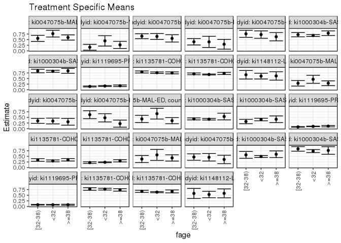

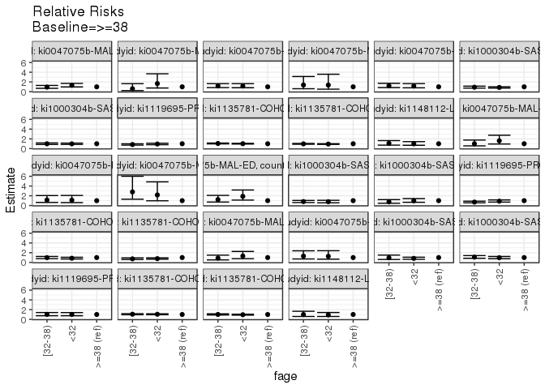

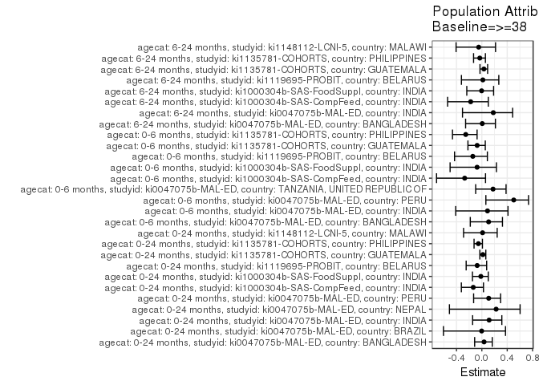

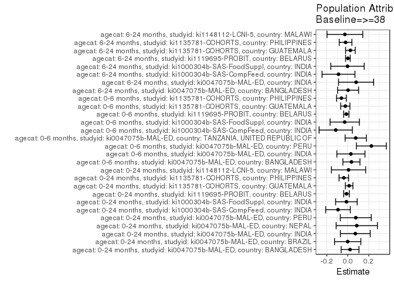

## Results Table

### Parameter: TSM

| agecat | studyid | country | intervention_level | baseline_level | estimate | ci_lower | ci_upper |
| --- | --- | --- | --- | --- | --- | --- | --- |
| 0-24 months | ki0047075b-MAL-ED | BANGLADESH | >=38 | NA | 0.5942029 | 0.4779542 | 0.7104516 |
| 0-24 months | ki0047075b-MAL-ED | BANGLADESH | <32 | NA | 0.7666667 | 0.6148142 | 0.9185192 |
| 0-24 months | ki0047075b-MAL-ED | BANGLADESH | [32-38) | NA | 0.5576923 | 0.4222517 | 0.6931329 |
| 0-24 months | ki0047075b-MAL-ED | BRAZIL | >=38 | NA | 0.2666667 | 0.1074132 | 0.4259201 |
| 0-24 months | ki0047075b-MAL-ED | BRAZIL | <32 | NA | 0.4444444 | 0.2134239 | 0.6754650 |
| 0-24 months | ki0047075b-MAL-ED | BRAZIL | [32-38) | NA | 0.1612903 | 0.0309906 | 0.2915900 |
| 0-24 months | ki0047075b-MAL-ED | INDIA | >=38 | NA | 0.5555556 | 0.3927301 | 0.7183810 |
| 0-24 months | ki0047075b-MAL-ED | INDIA | <32 | NA | 0.6415094 | 0.5119994 | 0.7710195 |
| 0-24 months | ki0047075b-MAL-ED | INDIA | [32-38) | NA | 0.6527778 | 0.5424662 | 0.7630894 |
| 0-24 months | ki0047075b-MAL-ED | NEPAL | >=38 | NA | 0.2941176 | 0.0761377 | 0.5120976 |
| 0-24 months | ki0047075b-MAL-ED | NEPAL | <32 | NA | 0.4000000 | 0.1504978 | 0.6495022 |
| 0-24 months | ki0047075b-MAL-ED | NEPAL | [32-38) | NA | 0.4042553 | 0.2630590 | 0.5454516 |
| 0-24 months | ki0047075b-MAL-ED | PERU | >=38 | NA | 0.6296296 | 0.4463996 | 0.8128597 |
| 0-24 months | ki0047075b-MAL-ED | PERU | <32 | NA | 0.7241379 | 0.5605032 | 0.8877727 |
| 0-24 months | ki0047075b-MAL-ED | PERU | [32-38) | NA | 0.7586207 | 0.6019523 | 0.9152890 |
| 0-24 months | ki1000304b-SAS-CompFeed | INDIA | >=38 | NA | 0.7843137 | 0.6799350 | 0.8886924 |
| 0-24 months | ki1000304b-SAS-CompFeed | INDIA | <32 | NA | 0.6825645 | 0.6414862 | 0.7236428 |
| 0-24 months | ki1000304b-SAS-CompFeed | INDIA | [32-38) | NA | 0.7200000 | 0.6255715 | 0.8144285 |
| 0-24 months | ki1000304b-SAS-FoodSuppl | INDIA | >=38 | NA | 0.8409091 | 0.7327061 | 0.9491120 |
| 0-24 months | ki1000304b-SAS-FoodSuppl | INDIA | <32 | NA | 0.8235294 | 0.7795251 | 0.8675337 |
| 0-24 months | ki1000304b-SAS-FoodSuppl | INDIA | [32-38) | NA | 0.8352941 | 0.7563476 | 0.9142406 |
| 0-24 months | ki1119695-PROBIT | BELARUS | >=38 | NA | 0.1774194 | 0.1435573 | 0.2112814 |
| 0-24 months | ki1119695-PROBIT | BELARUS | <32 | NA | 0.1677899 | 0.1484119 | 0.1871678 |
| 0-24 months | ki1119695-PROBIT | BELARUS | [32-38) | NA | 0.1482828 | 0.1264115 | 0.1701542 |
| 0-24 months | ki1135781-COHORTS | GUATEMALA | >=38 | NA | 0.7512953 | 0.7081565 | 0.7944342 |
| 0-24 months | ki1135781-COHORTS | GUATEMALA | <32 | NA | 0.7586207 | 0.7246215 | 0.7926199 |
| 0-24 months | ki1135781-COHORTS | GUATEMALA | [32-38) | NA | 0.7908497 | 0.7452638 | 0.8364356 |
| 0-24 months | ki1135781-COHORTS | PHILIPPINES | >=38 | NA | 0.7272727 | 0.6792134 | 0.7753321 |
| 0-24 months | ki1135781-COHORTS | PHILIPPINES | <32 | NA | 0.6788286 | 0.6587735 | 0.6988837 |
| 0-24 months | ki1135781-COHORTS | PHILIPPINES | [32-38) | NA | 0.7081784 | 0.6697582 | 0.7465987 |

[output cut: 54 more lines]

### Parameter: E(Y)

| agecat | studyid | country | intervention_level | baseline_level | estimate | ci_lower | ci_upper |
| --- | --- | --- | --- | --- | --- | --- | --- |
| 0-24 months | ki0047075b-MAL-ED | BANGLADESH | NA | NA | 0.6158940 | 0.5380580 | 0.6937301 |
| 0-24 months | ki0047075b-MAL-ED | BRAZIL | NA | NA | 0.2658228 | 0.1677841 | 0.3638614 |
| 0-24 months | ki0047075b-MAL-ED | INDIA | NA | NA | 0.6273292 | 0.5524091 | 0.7022493 |
| 0-24 months | ki0047075b-MAL-ED | NEPAL | NA | NA | 0.3797468 | 0.2720427 | 0.4874510 |
| 0-24 months | ki0047075b-MAL-ED | PERU | NA | NA | 0.7058824 | 0.6084428 | 0.8033219 |
| 0-24 months | ki1000304b-SAS-CompFeed | INDIA | NA | NA | 0.6908497 | 0.6505448 | 0.7311545 |
| 0-24 months | ki1000304b-SAS-FoodSuppl | INDIA | NA | NA | 0.8277512 | 0.7915095 | 0.8639929 |
| 0-24 months | ki1119695-PROBIT | BELARUS | NA | NA | 0.1652639 | 0.1464443 | 0.1840835 |
| 0-24 months | ki1135781-COHORTS | GUATEMALA | NA | NA | 0.7640277 | 0.7409463 | 0.7871090 |
| 0-24 months | ki1135781-COHORTS | PHILIPPINES | NA | NA | 0.6895967 | 0.6729013 | 0.7062922 |
| 0-24 months | ki1148112-LCNI-5 | MALAWI | NA | NA | 0.6226415 | 0.5299266 | 0.7153564 |
| 0-6 months | ki0047075b-MAL-ED | BANGLADESH | NA | NA | 0.3245033 | 0.2495788 | 0.3994278 |
| 0-6 months | ki0047075b-MAL-ED | INDIA | NA | NA | 0.3354037 | 0.2622476 | 0.4085599 |
| 0-6 months | ki0047075b-MAL-ED | PERU | NA | NA | 0.4470588 | 0.3407351 | 0.5533826 |
| 0-6 months | ki0047075b-MAL-ED | TANZANIA, UNITED REPUBLIC OF | NA | NA | 0.4300000 | 0.3324781 | 0.5275219 |
| 0-6 months | ki1000304b-SAS-CompFeed | INDIA | NA | NA | 0.4250164 | 0.3969651 | 0.4530677 |
| 0-6 months | ki1000304b-SAS-FoodSuppl | INDIA | NA | NA | 0.3894231 | 0.3425088 | 0.4363374 |
| 0-6 months | ki1119695-PROBIT | BELARUS | NA | NA | 0.0977693 | 0.0847778 | 0.1107608 |
| 0-6 months | ki1135781-COHORTS | GUATEMALA | NA | NA | 0.3212928 | 0.2930610 | 0.3495246 |
| 0-6 months | ki1135781-COHORTS | PHILIPPINES | NA | NA | 0.2392409 | 0.2238460 | 0.2546359 |
| 6-24 months | ki0047075b-MAL-ED | BANGLADESH | NA | NA | 0.4313725 | 0.3347836 | 0.5279615 |
| 6-24 months | ki0047075b-MAL-ED | INDIA | NA | NA | 0.4392523 | 0.3447732 | 0.5337315 |
| 6-24 months | ki1000304b-SAS-CompFeed | INDIA | NA | NA | 0.5024631 | 0.4586872 | 0.5462389 |
| 6-24 months | ki1000304b-SAS-FoodSuppl | INDIA | NA | NA | 0.7572016 | 0.7031798 | 0.8112234 |
| 6-24 months | ki1119695-PROBIT | BELARUS | NA | NA | 0.0761449 | 0.0622450 | 0.0900449 |
| 6-24 months | ki1135781-COHORTS | GUATEMALA | NA | NA | 0.7619048 | 0.7334389 | 0.7903706 |
| 6-24 months | ki1135781-COHORTS | PHILIPPINES | NA | NA | 0.6470302 | 0.6263581 | 0.6677023 |
| 6-24 months | ki1148112-LCNI-5 | MALAWI | NA | NA | 0.5555556 | 0.4523209 | 0.6587902 |

### Parameter: RR

| agecat | studyid | country | intervention_level | baseline_level | estimate | ci_lower | ci_upper |
| --- | --- | --- | --- | --- | --- | --- | --- |
| 0-24 months | ki0047075b-MAL-ED | BANGLADESH | >=38 | >=38 | 1.0000000 | 1.0000000 | 1.0000000 |
| 0-24 months | ki0047075b-MAL-ED | BANGLADESH | <32 | >=38 | 1.2902439 | 0.9767089 | 1.7044274 |
| 0-24 months | ki0047075b-MAL-ED | BANGLADESH | [32-38) | >=38 | 0.9385553 | 0.6871035 | 1.2820284 |
| 0-24 months | ki0047075b-MAL-ED | BRAZIL | >=38 | >=38 | 1.0000000 | 1.0000000 | 1.0000000 |
| 0-24 months | ki0047075b-MAL-ED | BRAZIL | <32 | >=38 | 1.6666667 | 0.7551006 | 3.6786859 |
| 0-24 months | ki0047075b-MAL-ED | BRAZIL | [32-38) | >=38 | 0.6048387 | 0.2214797 | 1.6517535 |
| 0-24 months | ki0047075b-MAL-ED | INDIA | >=38 | >=38 | 1.0000000 | 1.0000000 | 1.0000000 |
| 0-24 months | ki0047075b-MAL-ED | INDIA | <32 | >=38 | 1.1547170 | 0.8089383 | 1.6482978 |
| 0-24 months | ki0047075b-MAL-ED | INDIA | [32-38) | >=38 | 1.1750000 | 0.8377415 | 1.6480322 |
| 0-24 months | ki0047075b-MAL-ED | NEPAL | >=38 | >=38 | 1.0000000 | 1.0000000 | 1.0000000 |
| 0-24 months | ki0047075b-MAL-ED | NEPAL | <32 | >=38 | 1.3600000 | 0.5162322 | 3.5828837 |
| 0-24 months | ki0047075b-MAL-ED | NEPAL | [32-38) | >=38 | 1.3744681 | 0.6057768 | 3.1185783 |
| 0-24 months | ki0047075b-MAL-ED | PERU | >=38 | >=38 | 1.0000000 | 1.0000000 | 1.0000000 |
| 0-24 months | ki0047075b-MAL-ED | PERU | <32 | >=38 | 1.1501014 | 0.7956510 | 1.6624540 |
| 0-24 months | ki0047075b-MAL-ED | PERU | [32-38) | >=38 | 1.2048682 | 0.8432651 | 1.7215313 |
| 0-24 months | ki1000304b-SAS-CompFeed | INDIA | >=38 | >=38 | 1.0000000 | 1.0000000 | 1.0000000 |
| 0-24 months | ki1000304b-SAS-CompFeed | INDIA | <32 | >=38 | 0.8702697 | 0.7453639 | 1.0161069 |
| 0-24 months | ki1000304b-SAS-CompFeed | INDIA | [32-38) | >=38 | 0.9180000 | 0.7414593 | 1.1365749 |
| 0-24 months | ki1000304b-SAS-FoodSuppl | INDIA | >=38 | >=38 | 1.0000000 | 1.0000000 | 1.0000000 |
| 0-24 months | ki1000304b-SAS-FoodSuppl | INDIA | <32 | >=38 | 0.9793323 | 0.8519635 | 1.1257428 |
| 0-24 months | ki1000304b-SAS-FoodSuppl | INDIA | [32-38) | >=38 | 0.9933227 | 0.8467458 | 1.1652730 |
| 0-24 months | ki1119695-PROBIT | BELARUS | >=38 | >=38 | 1.0000000 | 1.0000000 | 1.0000000 |
| 0-24 months | ki1119695-PROBIT | BELARUS | <32 | >=38 | 0.9457246 | 0.8038970 | 1.1125742 |
| 0-24 months | ki1119695-PROBIT | BELARUS | [32-38) | >=38 | 0.8357760 | 0.7086579 | 0.9856962 |
| 0-24 months | ki1135781-COHORTS | GUATEMALA | >=38 | >=38 | 1.0000000 | 1.0000000 | 1.0000000 |
| 0-24 months | ki1135781-COHORTS | GUATEMALA | <32 | >=38 | 1.0097503 | 0.9388156 | 1.0860446 |
| 0-24 months | ki1135781-COHORTS | GUATEMALA | [32-38) | >=38 | 1.0526482 | 0.9703956 | 1.1418727 |
| 0-24 months | ki1135781-COHORTS | PHILIPPINES | >=38 | >=38 | 1.0000000 | 1.0000000 | 1.0000000 |
| 0-24 months | ki1135781-COHORTS | PHILIPPINES | <32 | >=38 | 0.9333893 | 0.8682132 | 1.0034582 |
| 0-24 months | ki1135781-COHORTS | PHILIPPINES | [32-38) | >=38 | 0.9737454 | 0.8939509 | 1.0606623 |

[output cut: 54 more lines]

### Parameter: PAR

| agecat | studyid | country | intervention_level | baseline_level | estimate | ci_lower | ci_upper |
| --- | --- | --- | --- | --- | --- | --- | --- |
| 0-24 months | ki0047075b-MAL-ED | BANGLADESH | >=38 | NA | 0.0216911 | -0.0632906 | 0.1066729 |
| 0-24 months | ki0047075b-MAL-ED | BRAZIL | >=38 | NA | -0.0008439 | -0.1261883 | 0.1245005 |
| 0-24 months | ki0047075b-MAL-ED | INDIA | >=38 | NA | 0.0717736 | -0.0705949 | 0.2141422 |
| 0-24 months | ki0047075b-MAL-ED | NEPAL | >=38 | NA | 0.0856292 | -0.1110071 | 0.2822655 |
| 0-24 months | ki0047075b-MAL-ED | PERU | >=38 | NA | 0.0762527 | -0.0711882 | 0.2236936 |
| 0-24 months | ki1000304b-SAS-CompFeed | INDIA | >=38 | NA | -0.0934641 | -0.2107629 | 0.0238348 |
| 0-24 months | ki1000304b-SAS-FoodSuppl | INDIA | >=38 | NA | -0.0131579 | -0.1159028 | 0.0895870 |
| 0-24 months | ki1119695-PROBIT | BELARUS | >=38 | NA | -0.0121555 | -0.0388349 | 0.0145239 |
| 0-24 months | ki1135781-COHORTS | GUATEMALA | >=38 | NA | 0.0127323 | -0.0231764 | 0.0486410 |
| 0-24 months | ki1135781-COHORTS | PHILIPPINES | >=38 | NA | -0.0376760 | -0.0831937 | 0.0078418 |
| 0-24 months | ki1148112-LCNI-5 | MALAWI | >=38 | NA | 0.0072569 | -0.1557788 | 0.1702926 |
| 0-6 months | ki0047075b-MAL-ED | BANGLADESH | >=38 | NA | 0.0346482 | -0.0466343 | 0.1159308 |
| 0-6 months | ki0047075b-MAL-ED | INDIA | >=38 | NA | 0.0298482 | -0.1041169 | 0.1638132 |
| 0-6 months | ki0047075b-MAL-ED | PERU | >=38 | NA | 0.2248366 | 0.0820782 | 0.3675950 |
| 0-6 months | ki0047075b-MAL-ED | TANZANIA, UNITED REPUBLIC OF | >=38 | NA | 0.0758333 | -0.0254096 | 0.1770763 |
| 0-6 months | ki1000304b-SAS-CompFeed | INDIA | >=38 | NA | -0.1149836 | -0.2734020 | 0.0434348 |
| 0-6 months | ki1000304b-SAS-FoodSuppl | INDIA | >=38 | NA | -0.0291816 | -0.1687879 | 0.1104247 |
| 0-6 months | ki1119695-PROBIT | BELARUS | >=38 | NA | -0.0139400 | -0.0393820 | 0.0115021 |
| 0-6 months | ki1135781-COHORTS | GUATEMALA | >=38 | NA | -0.0237551 | -0.0675872 | 0.0200769 |
| 0-6 months | ki1135781-COHORTS | PHILIPPINES | >=38 | NA | -0.0607591 | -0.1069703 | -0.0145478 |
| 6-24 months | ki0047075b-MAL-ED | BANGLADESH | >=38 | NA | 0.0028011 | -0.0976469 | 0.1032491 |
| 6-24 months | ki0047075b-MAL-ED | INDIA | >=38 | NA | 0.0792523 | -0.0879712 | 0.2464759 |
| 6-24 months | ki1000304b-SAS-CompFeed | INDIA | >=38 | NA | -0.0884460 | -0.2452587 | 0.0683667 |
| 6-24 months | ki1000304b-SAS-FoodSuppl | INDIA | >=38 | NA | -0.0027984 | -0.1617659 | 0.1561692 |
| 6-24 months | ki1119695-PROBIT | BELARUS | >=38 | NA | 0.0012214 | -0.0209463 | 0.0233891 |
| 6-24 months | ki1135781-COHORTS | GUATEMALA | >=38 | NA | 0.0250627 | -0.0207330 | 0.0708583 |
| 6-24 months | ki1135781-COHORTS | PHILIPPINES | >=38 | NA | -0.0212163 | -0.0815139 | 0.0390813 |
| 6-24 months | ki1148112-LCNI-5 | MALAWI | >=38 | NA | -0.0277778 | -0.1981199 | 0.1425643 |

### Parameter: PAF

| agecat | studyid | country | intervention_level | baseline_level | estimate | ci_lower | ci_upper |
| --- | --- | --- | --- | --- | --- | --- | --- |
| 0-24 months | ki0047075b-MAL-ED | BANGLADESH | >=38 | NA | 0.0352189 | -0.1132901 | 0.1639174 |
| 0-24 months | ki0047075b-MAL-ED | BRAZIL | >=38 | NA | -0.0031746 | -0.6051395 | 0.3730393 |
| 0-24 months | ki0047075b-MAL-ED | INDIA | >=38 | NA | 0.1144114 | -0.1453145 | 0.3152386 |
| 0-24 months | ki0047075b-MAL-ED | NEPAL | >=38 | NA | 0.2254902 | -0.5110053 | 0.6030024 |
| 0-24 months | ki0047075b-MAL-ED | PERU | >=38 | NA | 0.1080247 | -0.1295328 | 0.2956203 |
| 0-24 months | ki1000304b-SAS-CompFeed | INDIA | >=38 | NA | -0.1352886 | -0.3229520 | 0.0257544 |
| 0-24 months | ki1000304b-SAS-FoodSuppl | INDIA | >=38 | NA | -0.0158960 | -0.1479422 | 0.1009612 |
| 0-24 months | ki1119695-PROBIT | BELARUS | >=38 | NA | -0.0735520 | -0.2472270 | 0.0759389 |
| 0-24 months | ki1135781-COHORTS | GUATEMALA | >=38 | NA | 0.0166648 | -0.0314909 | 0.0625723 |
| 0-24 months | ki1135781-COHORTS | PHILIPPINES | >=38 | NA | -0.0546348 | -0.1228025 | 0.0093943 |
| 0-24 months | ki1148112-LCNI-5 | MALAWI | >=38 | NA | 0.0116550 | -0.2881702 | 0.2416950 |
| 0-6 months | ki0047075b-MAL-ED | BANGLADESH | >=38 | NA | 0.1067731 | -0.1821295 | 0.3250704 |
| 0-6 months | ki0047075b-MAL-ED | INDIA | >=38 | NA | 0.0889918 | -0.4122526 | 0.4123318 |
| 0-6 months | ki0047075b-MAL-ED | PERU | >=38 | NA | 0.5029240 | 0.0634044 | 0.7361886 |
| 0-6 months | ki0047075b-MAL-ED | TANZANIA, UNITED REPUBLIC OF | >=38 | NA | 0.1763566 | -0.0972907 | 0.3817605 |
| 0-6 months | ki1000304b-SAS-CompFeed | INDIA | >=38 | NA | -0.2705393 | -0.7141359 | 0.0582602 |
| 0-6 months | ki1000304b-SAS-FoodSuppl | INDIA | >=38 | NA | -0.0749354 | -0.5005081 | 0.2299368 |
| 0-6 months | ki1119695-PROBIT | BELARUS | >=38 | NA | -0.1425803 | -0.4300444 | 0.0870985 |
| 0-6 months | ki1135781-COHORTS | GUATEMALA | >=38 | NA | -0.0739361 | -0.2194069 | 0.0541805 |
| 0-6 months | ki1135781-COHORTS | PHILIPPINES | >=38 | NA | -0.2539660 | -0.4626242 | -0.0750750 |
| 6-24 months | ki0047075b-MAL-ED | BANGLADESH | >=38 | NA | 0.0064935 | -0.2559174 | 0.2140764 |
| 6-24 months | ki0047075b-MAL-ED | INDIA | >=38 | NA | 0.1804255 | -0.3050283 | 0.4852967 |
| 6-24 months | ki1000304b-SAS-CompFeed | INDIA | >=38 | NA | -0.1760249 | -0.5398925 | 0.1018629 |
| 6-24 months | ki1000304b-SAS-FoodSuppl | INDIA | >=38 | NA | -0.0036957 | -0.2372084 | 0.1857435 |
| 6-24 months | ki1119695-PROBIT | BELARUS | >=38 | NA | 0.0160404 | -0.3217623 | 0.2675110 |
| 6-24 months | ki1135781-COHORTS | GUATEMALA | >=38 | NA | 0.0328947 | -0.0291886 | 0.0912331 |
| 6-24 months | ki1135781-COHORTS | PHILIPPINES | >=38 | NA | -0.0327902 | -0.1303333 | 0.0563353 |
| 6-24 months | ki1148112-LCNI-5 | MALAWI | >=38 | NA | -0.0500000 | -0.4063855 | 0.2160756 |